# Sensitivity analyses Zn BLM

Cecilia Albert-Black

# Objectives

To conduct sensitivity analyses of two BLM assumptions

- **Carbonate charge balance**
  - Baseline: Closed system, measured DIC as input
  - Perturbed: Open system, no DIC input, alkalinity estimated by charge balance (assuming in equilibrium with atmospheric partial pressure)
- **Humic acid fraction of DOC**
  - Baseline: HA = 10% (suggested by the BLM manual)
  - Perturbed: HA = 80%

We’ll be conducting the sensitivity analysis on the BLM output in speciation mode only.

# 1. Setup

We will merge BLM output variables from the baseline conditions (closed system + HA 10%) and the perturbed scenarios (open system + HA 10% and closed system + HA 80%) from the clean Bioavailability Master Spreadsheet version 2 (pre-typology) and version 3 (with typological classification).

First, we’ll set the working directory and import each dataset as it’s own object

```r
library(readxl)

# -------------------------------------------------
# 1) Set working directory
# -------------------------------------------------
setwd("C:/Users/q4q/OneDrive - Oak Ridge National Laboratory/Research/Bioavailability Project/BLM_spatial_assessmt/Zinc/6. Sensitivity analyses")

# -------------------------------------------------
# 2) Store file paths once (so you don't repeat them)
# -------------------------------------------------
file_master3 <- "C:/Users/q4q/OneDrive - Oak Ridge National Laboratory/Research/Bioavailability Project/BLM_spatial_assessmt/Zinc/5. Statistical data analysis/Bioavailability_Master_Spreadsheet_Clean3.xlsx"

file_master2 <- "C:/Users/q4q/OneDrive - Oak Ridge National Laboratory/Research/Bioavailability Project/BLM_spatial_assessmt/Zinc/4. Exploratory data analysis/Bioavailability_Master_Spreadsheet_Clean2.xlsx"
```

Now we’ll read each file and create the following scenarios as their own objects

- ha_10_cs
- ha_10_os
- ha_80_cs

```r
library(dplyr)
read_scenario <- function(path, sheet) {
  read_excel(path, sheet = sheet)
}

ha_10_cs <- read_scenario(file_master3, "HA 10% Closed System")
ha_10_os <- read_scenario(file_master2, "HA 10% Open System")
ha_80_cs <- read_scenario(file_master2, "HA 80% Closed System")
```

Now we’ll add typology from ha_10_cs to each scenario

```r
library(dplyr)

typology_lookup <- ha_10_cs %>%
  dplyr::select(Sample_ID, Typology) %>%
  distinct()

ha_10_os <- ha_10_os %>%
  left_join(typology_lookup, by = "Sample_ID") %>%
  dplyr::select(Sample_ID, Typology, everything())

ha_80_cs <- ha_80_cs %>%
  left_join(typology_lookup, by = "Sample_ID") %>%
  dplyr::select(Sample_ID, Typology, everything())

ha_10_cs <- ha_10_cs %>%
  dplyr::select(Sample_ID, Typology, everything())

# quick sanity check: check if there are Sample_IDs that don't match (should be 0)
setdiff(ha_10_os$Sample_ID, ha_10_cs$Sample_ID)
```

```
## character(0)
```

```r
setdiff(ha_80_cs$Sample_ID, ha_10_cs$Sample_ID)
```

```
## character(0)
```

# 2. Carbonate assumption SA

## a. Select variables of interest

First, we’ll create a paired dataset

```r
library(dplyr)

# Only retain BLM speciation mode output variables in nM and nmol/g for simplicity and consistency (one column per variable and all in same units of measurement)
ha_10_cs <- ha_10_cs %>%
  dplyr::select(
    Sample_ID,
    ends_with("_nM"),
    ends_with("_nmol_kg"),
    # log-transformed variables
    -starts_with("log_"),
    # Remove BLM predictors
    -"DOC_nM",
    -"Ca_nM",
    -"Mg_nM",
    -"Na_nM",
    -"K_nM",
    -"SO4_nM",
    -"Cl_nM",
    -"pH",
    -"DIC_nM",
    -"Zn_nM",
    -"Cu_nM",
    # Remove toxicity variables
    -starts_with("Zn_Tox")
  )

ha_10_os <- ha_10_os %>%
  dplyr::select(
    Sample_ID,
    ends_with("_nM"),
    ends_with("_nmol_kg"),
    # log-transformed variables
    -starts_with("log_"),
    # BLM predictors
    -"DOC_nM",
    -"Ca_nM",
    -"Mg_nM",
    -"Na_nM",
    -"K_nM",
    -"SO4_nM",
    -"Cl_nM",
    -"pH",
    -"DIC_nM",
    -"Zn_nM",
    -"Cu_nM",
    # Remove toxicity variables
    -starts_with("Zn_Tox")
   )
```

## b. Calculate sensitivity metrics

### i. Delta

Delta is the absolute change in a response variable from baseline to the perturbed BLM system assumptions; calculated as y_s2 - y_s1.

```r
library(dplyr)
library(stringr)

# 1. Separate the numeric data
num1 <- ha_10_cs %>%
  dplyr::select(where(is.numeric))

num2 <- ha_10_os %>%
  dplyr::select(where(is.numeric))

# 2. Subtract num1-num2
delta_dic <- ha_10_os %>%
  dplyr::select(Sample_ID) %>%
  bind_cols(num2 - num1)

# 3. Check
delta_dic
```

```
## # A tibble: 386 × 31
##    Sample_ID Free_Zn_nM  ZnOH_nM Zn_OH_2_nM ZnCO3_nM ZnHCO3_nM ZnSO4_nM  ZnCl_nM
##    <chr>          <dbl>    <dbl>      <dbl>    <dbl>     <dbl>    <dbl>    <dbl>
##  1 WaDE_62     10.5      8.05e-2  0.00718   -0.996    -15.3     4.63e-2  3.44e-3
##  2 WaDE_63     -0.327   -3.74e-2 -0.0475     1.09       1.42   -6.30e-3 -1.19e-4
##  3 WaDE_64      2.45     2.41e-1  0.255     -3.82      -4.85    1.31e-2  4.32e-4
##  4 WaDE_65      0.0460   1.57e-3  0.000108   0.690      0.799  -5.35e-5 -2.08e-7
##  5 WaDE_66      0.00198  1.04e-4  0.0000321 -0.00884   -0.0450  7.95e-5  1.02e-6
##  6 WaDE_67      0.0195  -2.89e-4 -0.0000881  0.0611     0.465  -6.35e-4 -7.25e-6
##  7 WaDE_68      0.0126   3.18e-4  0.0000828 -0.00810   -0.0469  5.67e-5  2.46e-6
##  8 WaDE_69      1.54     2.75e-2  0.00558   -0.471     -3.28    7.81e-3  2.85e-4
##  9 WaDE_70      0.0288   2.23e-3  0.00184   -0.0605    -0.110   1.54e-4  5.85e-6
## 10 WaDE_71      2.12     1.84e-1  0.184     -3.60      -6.11    5.16e-2  1.02e-3
## # ℹ 376 more rows
## # ℹ 23 more variables: ZnS_nM <dbl>, TOrg_Zn_nM <dbl>, HCO3_nM <dbl>,
## #   H2_CO3_nM <dbl>, HS_nM <dbl>, H2S_nM <dbl>, MgHCO3_nM <dbl>,
## #   MgCO3_nM <dbl>, MgSO4_nM <dbl>, CaHCO3_nM <dbl>, CaCO3_nM <dbl>,
## #   CaSO4_nM <dbl>, TOrg_H_nM <dbl>, TOrg_Ca_nM <dbl>, TOrg_Mg_nM <dbl>,
## #   TOrg_Na_nM <dbl>, TOrg_K_nM <dbl>, BL_Zn_nmol_kg <dbl>,
## #   BL_Ca_nmol_kg <dbl>, BL_H_nmol_kg <dbl>, BL_Mg_nmol_kg <dbl>, …
```

Summarize delta by variable

```r
library(dplyr)
library(tidyr)

summary_delta_dic <- delta_dic %>%
  dplyr::select(where(is.numeric)) %>%
  summarise(across(everything(), list(
    min    = ~min(.x, na.rm = TRUE),
    q1     = ~quantile(.x, 0.25, na.rm = TRUE),
    median = ~median(.x, na.rm = TRUE),
    mean   = ~mean(.x, na.rm = TRUE),
    q3     = ~quantile(.x, 0.75, na.rm = TRUE),
    max    = ~max(.x, na.rm = TRUE),
    iqr    = ~IQR(.x, na.rm = TRUE)
  ))) %>%
  # Pivot so it's a readable list instead of 500 columns wide
  pivot_longer(everything(),
               names_to = c("Variable", ".value"),
               names_sep = "_(?!.*_)") # Splits at the last underscore

# Check
head(summary_delta_dic)
```

```
## # A tibble: 6 × 8
##   Variable        min        q1   median     mean      q3     max     iqr
##   <chr>         <dbl>     <dbl>    <dbl>    <dbl>   <dbl>   <dbl>   <dbl>
## 1 Free_Zn_nM  -15.4     1.12      4.27     7.66   10.5     80.5    9.36
## 2 ZnOH_nM      -5.49    0.0258    0.0771   0.0465  0.156    0.836  0.130
## 3 Zn_OH_2_nM  -85.7     0.00316   0.0139  -0.564   0.0407   1.01   0.0375
## 4 ZnCO3_nM    -15.8    -3.34     -1.84    -0.683  -0.812  131.     2.52
## 5 ZnHCO3_nM  -109.    -21.8     -13.8    -15.2    -4.82    29.2   17.0
## 6 ZnSO4_nM     -0.571   0.0168    0.0531   0.0736  0.111    0.694  0.0945
```

### ii. Percent change

Percentage of delta

```r
# Multiply all numeric columns by 100
percent_change_dic <- delta_dic %>%
  dplyr::select(where(is.numeric)) * 100

# Check
head(percent_change_dic)
```

```
##     Free_Zn_nM     ZnOH_nM   Zn_OH_2_nM   ZnCO3_nM    ZnHCO3_nM     ZnSO4_nM
## 1 1048.1084445  8.04615818  0.718108645  -99.57338 -1529.903704  4.628193662
## 2  -32.6693783 -3.73750197 -4.753050731  109.12004   141.981782 -0.629747990
## 3  245.3589332 24.08245825 25.463298137 -381.86254  -484.981122  1.309995862
## 4    4.5981663  0.15720064  0.010831613   69.03555    79.920137 -0.005349052
## 5    0.1975309  0.01036601  0.003207677   -0.88448    -4.504841  0.007946768
## 6    1.9540813 -0.02886164 -0.008810314    6.10525    46.528004 -0.063456185
##         ZnCl_nM        ZnS_nM  TOrg_Zn_nM    HCO3_nM   H2_CO3_nM         HS_nM
## 1  3.440204e-01  2.282357e-09  567.861402 -356569880 -50806253.2 -1.544382e-09
## 2 -1.185571e-02  8.801202e-11 -209.328125  117525418   1393877.8  1.014975e-10
## 3  4.323506e-02 -2.196992e-10  571.337486  -91864821  -1115294.1 -1.811049e-11
## 4 -2.078483e-05 -1.753623e-10 -153.877665  135889178   1503578.6  1.679435e-11
## 5  1.023812e-04 -4.367514e-11    5.184263   -2158165   -111904.4 -2.847149e-12
## 6 -7.254614e-04 -4.367514e-11  -55.492342    6998374    553351.9  3.217280e-12
##          H2S_nM    MgHCO3_nM    MgCO3_nM     MgSO4_nM    CaHCO3_nM     CaCO3_nM
```

[output cut: 27 more lines]

Check the distribution of the percent change

[figure not shown]

```r
library(dplyr)
library(tidyr)
library(ggplot2)

percent_change_dic %>%
  select(where(is.numeric)) %>%
  pivot_longer(
    cols = everything(),
    names_to = "variable",
    values_to = "value"
  ) %>%
  ggplot(aes(x = value)) +
  geom_histogram(bins = 40, na.rm = TRUE) +
  facet_wrap(~ variable, scales = "free", ncol = 5) +
  labs(
    title = "Distributions of numeric variables in lrr_dic",
    x = NULL,
    y = "Count"
  ) +
  theme_bw() +
  theme(
    strip.text = element_text(size = 8),
    axis.text.x = element_text(size = 7),
    axis.text.y = element_text(size = 7)
  )
```

Summarize percent change by variable

```r
library(dplyr)
library(tidyr)

summary_percent_change_dic <- percent_change_dic %>%
  dplyr::select(where(is.numeric)) %>%
  summarise(across(everything(), list(
    min    = ~min(.x, na.rm = TRUE),
    q1     = ~quantile(.x, 0.25, na.rm = TRUE),
    median = ~median(.x, na.rm = TRUE),
    mean   = ~mean(.x, na.rm = TRUE),
    q3     = ~quantile(.x, 0.75, na.rm = TRUE),
    max    = ~max(.x, na.rm = TRUE),
    iqr    = ~IQR(.x, na.rm = TRUE)
  ))) %>%
  # Pivot so it's a readable list instead of 500 columns wide
  pivot_longer(everything(),
               names_to = c("Variable", ".value"),
               names_sep = "_(?!.*_)") # Splits at the last underscore

# Check
head(summary_percent_change_dic)
```

```
## # A tibble: 6 × 8
##   Variable        min        q1   median     mean      q3     max     iqr
##   <chr>         <dbl>     <dbl>    <dbl>    <dbl>   <dbl>   <dbl>   <dbl>
## 1 Free_Zn_nM  -1538.    112.      427.     766.   1048.    8050.   936.
## 2 ZnOH_nM      -549.      2.58      7.71     4.65   15.6     83.6   13.0
## 3 Zn_OH_2_nM  -8570.      0.316     1.39   -56.4     4.07   101.     3.75
## 4 ZnCO3_nM    -1580.   -334.     -184.     -68.3   -81.2  13089.   252.
## 5 ZnHCO3_nM  -10923.  -2180.    -1380.   -1522.   -482.    2917.  1698.
## 6 ZnSO4_nM      -57.1     1.68      5.31     7.36   11.1     69.4    9.45
```

### iii. Log response ratio (LRR)

LRR describes the effect size between the two BLM assumption outputs, calculated as

log10(y_s2) - log10(y_s1)

```r
library(dplyr)

# 1. Log transform each dataframe
log_ha_10_cs <- ha_10_cs %>%
  mutate(across(where(is.numeric), log10))

log_ha_10_os <- ha_10_os %>%
  mutate(across(where(is.numeric), log10))

# 2. Separate the numeric log-transformed data
log_num1 <- log_ha_10_cs %>%
  dplyr::select(where(is.numeric))

log_num2 <- log_ha_10_os %>%
  dplyr::select(where(is.numeric))

# 3. Subtract num1-num2
lrr_dic <- ha_10_os %>%
  dplyr::select(Sample_ID) %>%
  bind_cols(log_num2 - log_num1)

# 4. Check
head(lrr_dic)
```

```
## # A tibble: 6 × 31
##   Sample_ID Free_Zn_nM   ZnOH_nM Zn_OH_2_nM ZnCO3_nM ZnHCO3_nM ZnSO4_nM  ZnCl_nM
##   <chr>          <dbl>     <dbl>      <dbl>    <dbl>     <dbl>    <dbl>    <dbl>
## 1 WaDE_62     0.274     0.287      0.292     -1.01     -1.01    3.02e-1  2.92e-1
## 2 WaDE_63    -0.0414   -0.0462    -0.0480     0.310     0.312  -5.15e-2 -4.81e-2
## 3 WaDE_64     0.0508    0.0565     0.0587    -0.0898   -0.0920  6.56e-2  5.87e-2
## 4 WaDE_65     0.0155    0.00433    0.000215   0.406     0.410  -1.54e-2 -2.15e-3
## 5 WaDE_66     0.000179  0.000408   0.000491  -0.0172   -0.0172  8.05e-4  5.18e-4
## 6 WaDE_67     0.000594 -0.000547  -0.000948   0.0999    0.100  -2.82e-3 -1.33e-3
## # ℹ 23 more variables: ZnS_nM <dbl>, TOrg_Zn_nM <dbl>, HCO3_nM <dbl>,
## #   H2_CO3_nM <dbl>, HS_nM <dbl>, H2S_nM <dbl>, MgHCO3_nM <dbl>,
## #   MgCO3_nM <dbl>, MgSO4_nM <dbl>, CaHCO3_nM <dbl>, CaCO3_nM <dbl>,
## #   CaSO4_nM <dbl>, TOrg_H_nM <dbl>, TOrg_Ca_nM <dbl>, TOrg_Mg_nM <dbl>,
## #   TOrg_Na_nM <dbl>, TOrg_K_nM <dbl>, BL_Zn_nmol_kg <dbl>,
## #   BL_Ca_nmol_kg <dbl>, BL_H_nmol_kg <dbl>, BL_Mg_nmol_kg <dbl>,
## #   BL_Na_nmol_kg <dbl>, BL_ZnOH_nmol_kg <dbl>
```

Check distribution of LRRs

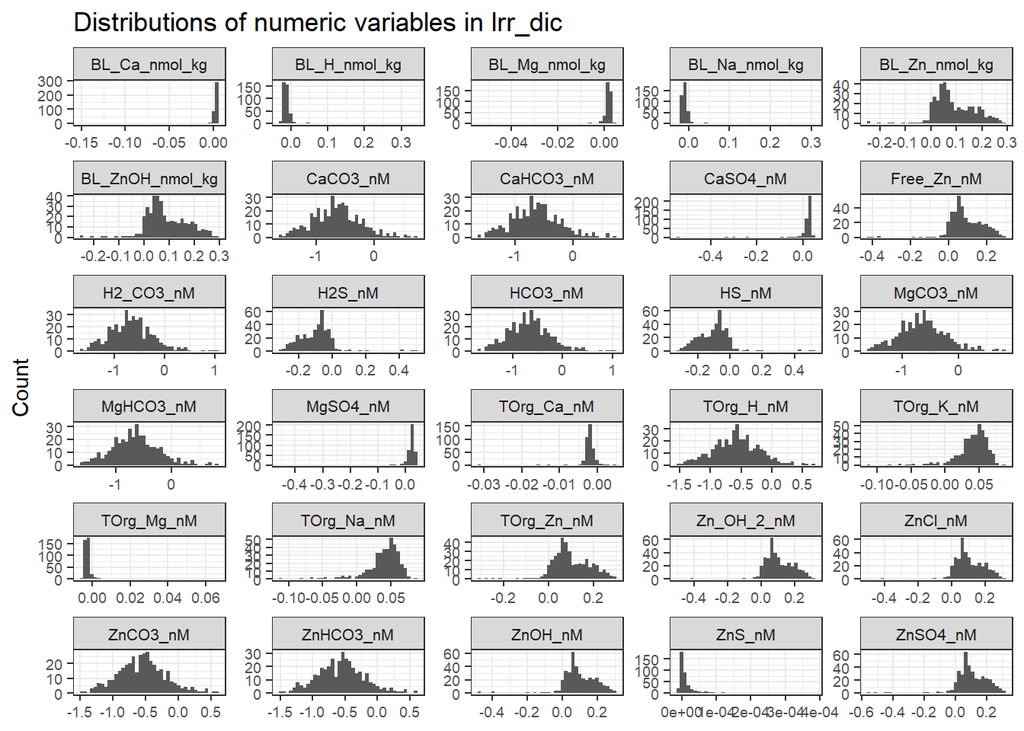

```r
library(dplyr)
library(tidyr)
library(ggplot2)

lrr_dic %>%
  select(where(is.numeric)) %>%
  pivot_longer(
    cols = everything(),
    names_to = "variable",
    values_to = "value"
  ) %>%
  ggplot(aes(x = value)) +
  geom_histogram(bins = 40, na.rm = TRUE) +
  facet_wrap(~ variable, scales = "free", ncol = 5) +
  labs(
    title = "Distributions of numeric variables in lrr_dic",
    x = NULL,
    y = "Count"
  ) +
  theme_bw() +
  theme(
    strip.text = element_text(size = 8),
    axis.text.x = element_text(size = 7),
    axis.text.y = element_text(size = 7)
  )
```

Summarize LRR for each numeric variable

```r
library(dplyr)
library(tidyr)

summary_lrr_dic <- lrr_dic %>%
  dplyr::select(where(is.numeric)) %>%
  summarise(across(everything(), list(
    min    = ~min(.x, na.rm = TRUE),
    q1     = ~quantile(.x, 0.25, na.rm = TRUE),
    median = ~median(.x, na.rm = TRUE),
    mean   = ~mean(.x, na.rm = TRUE),
    q3     = ~quantile(.x, 0.75, na.rm = TRUE),
    max    = ~max(.x, na.rm = TRUE),
    iqr    = ~IQR(.x, na.rm = TRUE)
  ))) %>%
  # Pivot so it's a readable list instead of 500 columns wide
  pivot_longer(everything(),
               names_to = c("Variable", ".value"),
               names_sep = "_(?!.*_)") # Splits at the last underscore

# Check
head(summary_lrr_dic)
```

```
## # A tibble: 6 × 8
##   Variable      min      q1  median    mean     q3   max   iqr
##   <chr>       <dbl>   <dbl>   <dbl>   <dbl>  <dbl> <dbl> <dbl>
## 1 Free_Zn_nM -0.419  0.0431  0.0773  0.0917  0.155 0.291 0.112
## 2 ZnOH_nM    -0.467  0.0487  0.0846  0.0979  0.165 0.304 0.116
## 3 Zn_OH_2_nM -0.498  0.0511  0.0875  0.100   0.169 0.308 0.117
## 4 ZnCO3_nM   -1.49  -0.796  -0.555  -0.557  -0.339 0.573 0.456
## 5 ZnHCO3_nM  -1.49  -0.799  -0.559  -0.560  -0.342 0.591 0.457
## 6 ZnSO4_nM   -0.552  0.0559  0.0936  0.106   0.176 0.318 0.121
```

### iv. Robustness

To assess directional consistency in LRR, we’ll summarize how many variables had a + or - LRR for each variable

```r
library(dplyr)

robustness_dic <- lrr_dic %>%
  dplyr::select(where(is.numeric)) %>%
  summarize(across(everything(), list(
    positive = ~sum(.x > 0, na.rm = TRUE),
    negative = ~sum(.x < 0, na.rm = TRUE),
    zero = ~sum(.x == 0, na.rm = TRUE)
  ))) %>%
  # Pivot for readability
  pivot_longer(everything(),
               names_to = c("Variable", ".value"),
               names_sep = "_(?!.*_)") %>%
  # Add the ratio of positive/negative LRR values
  mutate(ratio = positive/negative)

# Check
head(robustness_dic)
```

```
## # A tibble: 6 × 5
##   Variable   positive negative  zero   ratio
##   <chr>         <int>    <int> <int>   <dbl>
## 1 Free_Zn_nM      362       24     0 15.1
## 2 ZnOH_nM         364       22     0 16.5
## 3 Zn_OH_2_nM      365       21     0 17.4
## 4 ZnCO3_nM         23      363     0  0.0634
## 5 ZnHCO3_nM        23      363     0  0.0634
## 6 ZnSO4_nM        363       23     0 15.8
```

## c. Export SA results

Now we’ll compile all of the output to one excel sheet

```r
library(openxlsx)

# Create a list of all output objects
dic_sa_list <- list(
  "Delta"              = summary_delta_dic,
  "Percent Change"     = summary_percent_change_dic,
  "Log Response Ratio"        = summary_lrr_dic,
  "Robustness"         = robustness_dic
)

# Write into excel file
write.xlsx(dic_sa_list, file = "Carbonate_system_SA.xlsx", overwrite = TRUE)
```

## d. Plots

Since the percent changes were not normally distributed, we’ll plot the median and inter quartile ranges (IQRs) for each variable

### i. Percent change

```r
library(dplyr)

# 1. Pivot table: turn columns into rows
long_percent_change_dic <- percent_change_dic %>%
  pivot_longer(cols = everything(),
               names_to = "Variable",
               values_to = "Value") %>%
  # Calculate the stats
  group_by(Variable) %>%
  summarize(
    median = median(Value, na.rm = TRUE),
    q1 = quantile(Value, 0.25, na.rm = TRUE),
    q3 = quantile(Value, 0.75, na.rm = TRUE)
  ) %>%
  # Sort variables by median value
  mutate(Variable = reorder(Variable, median))


# 2. Plot
library(ggplot2)

pc_plot <- ggplot(long_percent_change_dic, aes(y = Variable, x = median)) +
  geom_col(aes(fill = median)) +
  geom_errorbar(aes(xmin = q1, xmax = q3), width = 0.25) +
  geom_vline(xintercept = 0, linetype = "dashed", color = "grey40") +
  scale_fill_gradient2(
    low = "red3", mid = "grey95", high = "steelblue4", midpoint = 0) +
  labs(x = "Percent Change (Median ± IQR)", y = NULL,
       title = "Percent Change Summary for Zn BLM",
       subtitle = "Closed system to open system BLM") +
  theme_bw() +
  theme(axis.text.y = element_text(size = 8)) +
  guides(fill = "none")

# 3. Save plot

# Define output directory
out_dir <- "Plots of DIC SA"

# Create folder if it doesn't exist
if (!dir.exists(out_dir)) {
  dir.create(out_dir, recursive = TRUE)
}

# Save plot
ggsave(
  filename = file.path(out_dir, "Percent_Change_DIC_SA.png"),
  plot = pc_plot,
  width = 10,
  height = 8,
  units = "in",
  dpi = "print"
)
```

### ii. LRR

Since the LRRs were not normally distributed, we’ll plot the median and inter quartile ranges (IQRs) for each variable

```r
library(dplyr)

# 1. Pivot table: turn columns into rows
long_lrr_dic <- lrr_dic %>%
  pivot_longer(cols = -Sample_ID,
               names_to = "Variable",
               values_to = "Value") %>%
  # Calculate the stats
  group_by(Variable) %>%
  summarize(
    median = median(Value, na.rm = TRUE),
    q1 = quantile(Value, 0.25, na.rm = TRUE),
    q3 = quantile(Value, 0.75, na.rm = TRUE)
  ) %>%
  # Sort variables by median value
  mutate(Variable = reorder(Variable, median))


# 2. Plot
library(ggplot2)

lrr_plot <- ggplot(long_lrr_dic, aes(y = Variable, x = median)) +
  geom_col(aes(fill = median)) +
  geom_errorbar(aes(xmin = q1, xmax = q3), width = 0.25) +
  geom_vline(xintercept = 0, linetype = "dashed", color = "grey40") +
  scale_fill_gradient2(
    low = "red3", mid = "grey95", high = "steelblue4", midpoint = 0) +
  labs(x = "LRR (Median ± IQR)", y = NULL,
       title = "Log Response Ratio (LRR) Summary for Zn BLM",
       subtitle = "Closed system to open system BLM") +
  theme_bw() +
  theme(axis.text.y = element_text(size = 8)) +
  guides(fill = "none")

# 3. Save plot
out_dir <- "Plots of DIC SA"
# Save plot
ggsave(
  filename = file.path(out_dir, "LRR_DIC_SA.png"),
  plot = lrr_plot,
  width = 10,
  height = 8,
  units = "in",
  dpi = "print"
)
```

# 3. Humic acid assumption SA

## a. Select variables of interest

First, we’ll create a paired dataset

```r
library(dplyr)

# Only retain variables in nM and nmol/g for simplicity and consistency (one column per variable and all in same units of measurement)

# Already done for ha_10_cs, we still need to got ha_80_cs

ha_80_cs <- ha_80_cs %>%
  dplyr::select(
    Sample_ID,
    ends_with("_nM"),
    ends_with("_nmol_kg"),
    # log-transformed variables
    -starts_with("log_"),
    # BLM predictors
    -"DOC_nM",
    -"Ca_nM",
    -"Mg_nM",
    -"Na_nM",
    -"K_nM",
    -"SO4_nM",
    -"Cl_nM",
    -"pH",
    -"DIC_nM",
    -"Zn_nM",
    -"Cu_nM",
    # Remove toxicity variables
    -starts_with("Zn_Tox")
   )

# Check
str(ha_80_cs)
```

```
## tibble [386 × 31] (S3: tbl_df/tbl/data.frame)
##  $ Sample_ID      : chr [1:386] "WaDE_62" "WaDE_63" "WaDE_64" "WaDE_65" ...
##  $ Free_Zn_nM     : num [1:386] 10.49 3.76 16.44 1.02 2.42 ...
##  $ ZnOH_nM        : num [1:386] 0.0755 0.3879 1.439 0.1264 0.0557 ...
##  $ Zn_OH_2_nM     : num [1:386] 0.00658 0.47516 1.46153 0.17668 0.01432 ...
##  $ ZnCO3_nM       : num [1:386] 0.97 1.097 16.972 0.356 0.115 ...
##  $ ZnHCO3_nM      : num [1:386] 14.889 1.416 21.097 0.406 0.583 ...
##  $ ZnSO4_nM       : num [1:386] 0.04042 0.05887 0.06672 0.00123 0.02158 ...
##  $ ZnCl_nM        : num [1:386] 3.15e-03 1.18e-03 2.48e-03 3.37e-05 4.32e-04 ...
##  $ ZnS_nM         : num [1:386] 9.99e-08 1.00e-07 1.00e-07 1.00e-07 9.99e-08 ...
##  $ TOrg_Zn_nM     : num [1:386] 9.53 21.01 57.53 68.63 28.4 ...
##  $ HCO3_nM        : num [1:386] 3750274 911617 3133210 857612 538060 ...
##  $ H2_CO3_nM      : num [1:386] 534695 10895 38504 9638 28027 ...
##  $ HS_nM          : num [1:386] 3.54e-11 7.97e-12 1.67e-12 2.31e-11 4.26e-11 ...
##  $ H2S_nM         : num [1:386] 2.01e-11 3.90e-13 8.08e-14 1.06e-12 8.80e-12 ...
```

[output cut: 17 more lines]

## b. Calculate sensitivity metrics

### i. Delta

Delta is the absolute change in a response variable from baseline to the perturbed BLM system assumptions; calculated as y_s2 - y_s1.

```r
library(dplyr)
library(stringr)

# 1. Separate the numeric data
num1 <- ha_10_cs %>%
  dplyr::select(where(is.numeric))

num2 <- ha_80_cs %>%
  dplyr::select(where(is.numeric))

# 2. Subtract num1-num2
delta_ha <- ha_10_os %>%
  dplyr::select(Sample_ID) %>%
  bind_cols(num2 - num1)

# 3. Check
delta_ha
```

```
## # A tibble: 386 × 31
##    Sample_ID Free_Zn_nM  ZnOH_nM Zn_OH_2_nM ZnCO3_nM ZnHCO3_nM ZnSO4_nM  ZnCl_nM
##    <chr>          <dbl>    <dbl>      <dbl>    <dbl>     <dbl>    <dbl>    <dbl>
##  1 WaDE_62      -1.44   -0.0104   -0.000904 -0.133     -2.05   -5.56e-3 -4.33e-4
##  2 WaDE_63       0.167   0.0172    0.0211    0.0482     0.0622  2.59e-3  5.20e-5
##  3 WaDE_64      -3.36   -0.294    -0.298    -3.47      -4.31   -1.36e-2 -5.07e-4
##  4 WaDE_65      -0.245  -0.0304   -0.0425   -0.0894    -0.102  -3.08e-4 -8.45e-6
##  5 WaDE_66      -2.37   -0.0545   -0.0140   -0.113     -0.574  -2.13e-2 -4.26e-4
##  6 WaDE_67      -8.74   -0.141    -0.0247   -0.145     -1.10   -6.02e-2 -1.46e-3
##  7 WaDE_68      -0.0534 -0.00115  -0.000285 -0.00475   -0.0274 -1.68e-4 -8.42e-6
##  8 WaDE_69      -0.556  -0.00917  -0.00181  -0.0910    -0.633  -2.37e-3 -9.23e-5
##  9 WaDE_70      -0.117  -0.00796  -0.00629  -0.0478    -0.0861 -4.72e-4 -2.00e-5
## 10 WaDE_71      -0.132  -0.0106   -0.0102   -0.0997    -0.168  -2.80e-3 -5.83e-5
## # ℹ 376 more rows
## # ℹ 23 more variables: ZnS_nM <dbl>, TOrg_Zn_nM <dbl>, HCO3_nM <dbl>,
## #   H2_CO3_nM <dbl>, HS_nM <dbl>, H2S_nM <dbl>, MgHCO3_nM <dbl>,
## #   MgCO3_nM <dbl>, MgSO4_nM <dbl>, CaHCO3_nM <dbl>, CaCO3_nM <dbl>,
## #   CaSO4_nM <dbl>, TOrg_H_nM <dbl>, TOrg_Ca_nM <dbl>, TOrg_Mg_nM <dbl>,
## #   TOrg_Na_nM <dbl>, TOrg_K_nM <dbl>, BL_Zn_nmol_kg <dbl>,
## #   BL_Ca_nmol_kg <dbl>, BL_H_nmol_kg <dbl>, BL_Mg_nmol_kg <dbl>, …
```

Summarize delta by variable

```r
library(dplyr)
library(tidyr)

summary_delta_ha <- delta_ha %>%
  dplyr::select(where(is.numeric)) %>%
  summarise(across(everything(), list(
    min    = ~min(.x, na.rm = TRUE),
    q1     = ~quantile(.x, 0.25, na.rm = TRUE),
    median = ~median(.x, na.rm = TRUE),
    mean   = ~mean(.x, na.rm = TRUE),
    q3     = ~quantile(.x, 0.75, na.rm = TRUE),
    max    = ~max(.x, na.rm = TRUE),
    iqr    = ~IQR(.x, na.rm = TRUE)
  ))) %>%
  # Pivot so it's a readable list instead of 500 columns wide
  pivot_longer(everything(),
               names_to = c("Variable", ".value"),
               names_sep = "_(?!.*_)") # Splits at the last underscore

# Check
head(summary_delta_ha)
```

```
## # A tibble: 6 × 8
##   Variable       min      q1   median    mean       q3    max    iqr
##   <chr>        <dbl>   <dbl>    <dbl>   <dbl>    <dbl>  <dbl>  <dbl>
## 1 Free_Zn_nM -34.1   -5.42   -3.18    -4.20   -1.73     3.79  3.69
## 2 ZnOH_nM     -0.394 -0.0826 -0.0468  -0.0410 -0.0260   2.18  0.0565
## 3 Zn_OH_2_nM  -0.319 -0.0247 -0.00980  0.173  -0.00339 20.4   0.0213
## 4 ZnCO3_nM    -3.47  -0.637  -0.405   -0.337  -0.214   12.8   0.423
## 5 ZnHCO3_nM  -20.0   -4.54   -2.77    -3.43   -1.48     4.31  3.06
## 6 ZnSO4_nM    -0.487 -0.0597 -0.0234  -0.0460 -0.0111   0.131 0.0486
```

### ii. Percent change

Percentage of delta

```r
# Multiply all numeric columns by 100
percent_change_ha <- delta_ha %>%
  dplyr::select(where(is.numeric)) * 100

# Check
head(percent_change_ha)
```

```
##   Free_Zn_nM    ZnOH_nM   Zn_OH_2_nM    ZnCO3_nM   ZnHCO3_nM    ZnSO4_nM
## 1 -144.09540  -1.037929  -0.09037502  -13.349077 -204.827177 -0.55634178
## 2   16.68743   1.721659   2.10872986    4.819734    6.219902  0.25852619
## 3 -335.55310 -29.379799 -29.84069658 -346.928708 -431.253433 -1.36409842
## 4  -24.48318  -3.040124  -4.24977414   -8.940140  -10.189502 -0.03078471
## 5 -236.85915  -5.452712  -1.40265291  -11.327407  -57.424188 -2.12554661
## 6 -873.73215 -14.053008  -2.47466457  -14.504204 -110.043602 -6.01808256
##         ZnCl_nM        ZnS_nM TOrg_Zn_nM    HCO3_nM   H2_CO3_nM         HS_nM
## 1 -0.0433302699 -4.830735e-10  363.50495  -46030.62  -6868.5040  4.279348e-10
## 2  0.0051989988  5.267486e-10  -32.33196  -42183.09   -512.0455 -3.695890e-11
## 3 -0.0506841314  2.633743e-10 1172.28558  -62980.69   -782.1654  2.828023e-11
## 4 -0.0008448771 -1.316872e-10   48.30746 -710686.44  -7998.1874  4.483227e-10
## 5 -0.0425631427 -2.062658e-09  312.36807 -138540.05  -7219.3870  2.107184e-09
## 6 -0.1461945690 -1.975307e-09 1008.40086 -143761.28 -11375.9597  1.635540e-09
##          H2S_nM MgHCO3_nM   MgCO3_nM  MgSO4_nM   CaHCO3_nM     CaCO3_nM
```

[output cut: 27 more lines]

Check the distribution of percent change

[figure not shown]

```r
library(dplyr)
library(tidyr)
library(ggplot2)

percent_change_ha %>%
  select(where(is.numeric)) %>%
  pivot_longer(
    cols = everything(),
    names_to = "variable",
    values_to = "value"
  ) %>%
  ggplot(aes(x = value)) +
  geom_histogram(bins = 40, na.rm = TRUE) +
  facet_wrap(~ variable, scales = "free", ncol = 5) +
  labs(
    title = "Distributions of numeric variables in lrr_dic",
    x = NULL,
    y = "Count"
  ) +
  theme_bw() +
  theme(
    strip.text = element_text(size = 8),
    axis.text.x = element_text(size = 7),
    axis.text.y = element_text(size = 7)
  )
```

Summarize percent change by variable

```r
library(dplyr)
library(tidyr)

summary_percent_change_ha <- percent_change_ha %>%
  dplyr::select(where(is.numeric)) %>%
  summarise(across(everything(), list(
    min    = ~min(.x, na.rm = TRUE),
    q1     = ~quantile(.x, 0.25, na.rm = TRUE),
    median = ~median(.x, na.rm = TRUE),
    mean   = ~mean(.x, na.rm = TRUE),
    q3     = ~quantile(.x, 0.75, na.rm = TRUE),
    max    = ~max(.x, na.rm = TRUE),
    iqr    = ~IQR(.x, na.rm = TRUE)
  ))) %>%
  # Pivot so it's a readable list instead of 500 columns wide
  pivot_longer(everything(),
               names_to = c("Variable", ".value"),
               names_sep = "_(?!.*_)") # Splits at the last underscore

# Check
head(summary_percent_change_ha)
```

```
## # A tibble: 6 × 8
##   Variable       min      q1   median    mean       q3    max    iqr
##   <chr>        <dbl>   <dbl>    <dbl>   <dbl>    <dbl>  <dbl>  <dbl>
## 1 Free_Zn_nM -3411.  -542.   -318.    -420.   -173.     379.  369.
## 2 ZnOH_nM      -39.4   -8.26   -4.68    -4.10   -2.60   218.    5.65
## 3 Zn_OH_2_nM   -31.9   -2.47   -0.980   17.3    -0.339 2039.    2.13
## 4 ZnCO3_nM    -347.   -63.7   -40.5    -33.7   -21.4   1277.   42.3
## 5 ZnHCO3_nM  -1999.  -454.   -277.    -343.   -148.     431.  306.
## 6 ZnSO4_nM     -48.7   -5.97   -2.34    -4.60   -1.11    13.1   4.86
```

### iii. LRR

LRR describes the effect size between the two BLM assumption outputs, calculated as

log10(y_s2) - log10(y_s1)

```r
library(dplyr)

# 1. Log transform each dataframe
log_ha_10_cs <- ha_10_cs %>%
  mutate(across(where(is.numeric), log10))

log_ha_80_cs <- ha_80_cs %>%
  mutate(across(where(is.numeric), log10))

# 2. Separate the numeric log-transformed data
log_num1 <- log_ha_10_cs %>%
  dplyr::select(where(is.numeric))

log_num2 <- log_ha_80_cs %>%
  dplyr::select(where(is.numeric))

# 3. Subtract num1-num2
lrr_ha <- ha_10_os %>%
  dplyr::select(Sample_ID) %>%
  bind_cols(log_num2 - log_num1)

# 4. Check
head(lrr_ha)
```

```
## # A tibble: 6 × 31
##   Sample_ID Free_Zn_nM ZnOH_nM Zn_OH_2_nM ZnCO3_nM ZnHCO3_nM ZnSO4_nM ZnCl_nM
##   <chr>          <dbl>   <dbl>      <dbl>    <dbl>     <dbl>    <dbl>   <dbl>
## 1 WaDE_62      -0.0559 -0.0559    -0.0559  -0.0560   -0.0560  -0.0560 -0.0560
## 2 WaDE_63       0.0197  0.0197     0.0197   0.0195    0.0195   0.0195  0.0195
## 3 WaDE_64      -0.0807 -0.0807    -0.0807  -0.0808   -0.0808  -0.0808 -0.0808
## 4 WaDE_65      -0.0936 -0.0936    -0.0936  -0.0972   -0.0972  -0.0972 -0.0972
## 5 WaDE_66      -0.297  -0.297     -0.297   -0.298    -0.298   -0.298  -0.298
## 6 WaDE_67      -0.412  -0.412     -0.412   -0.414    -0.414   -0.414  -0.414
## # ℹ 23 more variables: ZnS_nM <dbl>, TOrg_Zn_nM <dbl>, HCO3_nM <dbl>,
## #   H2_CO3_nM <dbl>, HS_nM <dbl>, H2S_nM <dbl>, MgHCO3_nM <dbl>,
## #   MgCO3_nM <dbl>, MgSO4_nM <dbl>, CaHCO3_nM <dbl>, CaCO3_nM <dbl>,
## #   CaSO4_nM <dbl>, TOrg_H_nM <dbl>, TOrg_Ca_nM <dbl>, TOrg_Mg_nM <dbl>,
## #   TOrg_Na_nM <dbl>, TOrg_K_nM <dbl>, BL_Zn_nmol_kg <dbl>,
## #   BL_Ca_nmol_kg <dbl>, BL_H_nmol_kg <dbl>, BL_Mg_nmol_kg <dbl>,
## #   BL_Na_nmol_kg <dbl>, BL_ZnOH_nmol_kg <dbl>
```

Check distribution of LRRs

[figure not shown]

```r
library(dplyr)
library(tidyr)
library(ggplot2)

lrr_ha %>%
  select(where(is.numeric)) %>%
  pivot_longer(
    cols = everything(),
    names_to = "variable",
    values_to = "value"
  ) %>%
  ggplot(aes(x = value)) +
  geom_histogram(bins = 40, na.rm = TRUE) +
  facet_wrap(~ variable, scales = "free", ncol = 5) +
  labs(
    title = "Distributions of numeric variables in lrr_dic",
    x = NULL,
    y = "Count"
  ) +
  theme_bw() +
  theme(
    strip.text = element_text(size = 8),
    axis.text.x = element_text(size = 7),
    axis.text.y = element_text(size = 7)
  )
```

Summarize LRR for each numeric variable

```r
library(dplyr)
library(tidyr)

summary_lrr_ha <- lrr_ha %>%
  dplyr::select(where(is.numeric)) %>%
  summarise(across(everything(), list(
    min    = ~min(.x, na.rm = TRUE),
    q1     = ~quantile(.x, 0.25, na.rm = TRUE),
    median = ~median(.x, na.rm = TRUE),
    mean   = ~mean(.x, na.rm = TRUE),
    q3     = ~quantile(.x, 0.75, na.rm = TRUE),
    max    = ~max(.x, na.rm = TRUE),
    iqr    = ~IQR(.x, na.rm = TRUE)
  ))) %>%
  # Pivot so it's a readable list instead of 500 columns wide
  pivot_longer(everything(),
               names_to = c("Variable", ".value"),
               names_sep = "_(?!.*_)") # Splits at the last underscore

# Check
head(summary_lrr_ha)
```

```
## # A tibble: 6 × 8
##   Variable      min     q1  median    mean      q3    max    iqr
##   <chr>       <dbl>  <dbl>   <dbl>   <dbl>   <dbl>  <dbl>  <dbl>
## 1 Free_Zn_nM -0.412 -0.135 -0.0758 -0.0940 -0.0438 0.0927 0.0909
## 2 ZnOH_nM    -0.412 -0.135 -0.0758 -0.0940 -0.0438 0.0927 0.0909
## 3 Zn_OH_2_nM -0.412 -0.135 -0.0758 -0.0940 -0.0438 0.0927 0.0909
## 4 ZnCO3_nM   -0.414 -0.135 -0.0760 -0.0943 -0.0438 0.0925 0.0912
## 5 ZnHCO3_nM  -0.414 -0.135 -0.0759 -0.0943 -0.0438 0.0925 0.0912
## 6 ZnSO4_nM   -0.415 -0.135 -0.0760 -0.0944 -0.0438 0.0925 0.0913
```

### iv. Robustness

To assess directional consistency in LRR, we’ll summarize how many variables had a + or - LRR for each variable

```r
library(dplyr)

robustness_ha <- lrr_ha %>%
  dplyr::select(where(is.numeric)) %>%
  summarize(across(everything(), list(
    positive = ~sum(.x > 0, na.rm = TRUE),
    negative = ~sum(.x < 0, na.rm = TRUE),
    zero = ~sum(.x == 0, na.rm = TRUE)
  ))) %>%
  # Pivot for readability
  pivot_longer(everything(),
               names_to = c("Variable", ".value"),
               names_sep = "_(?!.*_)") %>%
  # Add the ratio of positive/negative LRR values
  mutate(ratio = positive/negative)

# Check
head(robustness_ha)
```

```
## # A tibble: 6 × 5
##   Variable   positive negative  zero  ratio
##   <chr>         <int>    <int> <int>  <dbl>
## 1 Free_Zn_nM       18      368     0 0.0489
## 2 ZnOH_nM          18      368     0 0.0489
## 3 Zn_OH_2_nM       18      368     0 0.0489
## 4 ZnCO3_nM         18      368     0 0.0489
## 5 ZnHCO3_nM        18      368     0 0.0489
## 6 ZnSO4_nM         18      368     0 0.0489
```

## c. Export SA results

Now we’ll compile all of the output to one excel sheet

```r
library(openxlsx)

# Create a list of all output objects
ha_sa_list <- list(
  "Delta"              = summary_delta_ha,
  "Percent Change"     = summary_percent_change_ha,
  "Log Response Ratio" = summary_lrr_ha,
  "Robustness"         = robustness_ha
)

# Write into excel file
write.xlsx(ha_sa_list, file = "Humic_acid_SA.xlsx", overwrite = TRUE)
```

## d. Plots

### i. Percent change

```r
library(dplyr)

# 1. Pivot table: turn columns into rows
long_percent_change_ha <- percent_change_ha %>%
  pivot_longer(cols = everything(),
               names_to = "Variable",
               values_to = "Value") %>%
  # Calculate the stats
  group_by(Variable) %>%
  summarize(
    median = median(Value, na.rm = TRUE),
    q1 = quantile(Value, 0.25, na.rm = TRUE),
    q3 = quantile(Value, 0.75, na.rm = TRUE)
  ) %>%
  # Sort variables by median value
  mutate(Variable = reorder(Variable, median))


# 2. Plot
library(ggplot2)

pc_plot <- ggplot(long_percent_change_ha, aes(y = Variable, x = median)) +
  geom_col(aes(fill = median)) +
  geom_errorbar(aes(xmin = q1, xmax = q3), width = 0.25) +
  geom_vline(xintercept = 0, linetype = "dashed", color = "grey40") +
  scale_fill_gradient2(
    low = "red3", mid = "grey95", high = "steelblue4", midpoint = 0) +
  labs(x = "Percent Change (Median ± IQR)", y = NULL,
       title = "Percent Change Summary for Zn BLM",
       subtitle = "Low (10%) to high (80%) humic acid content of DOC") +
  theme_bw() +
  theme(axis.text.y = element_text(size = 8)) +
  guides(fill = "none")

# 3. Save plot

# Define output directory
out_dir <- "Plots of HA SA"

# Create folder if it doesn't exist
if (!dir.exists(out_dir)) {
  dir.create(out_dir, recursive = TRUE)
}

# Save plot
ggsave(
  filename = file.path(out_dir, "Percent_Change_HA_SA.png"),
  plot = pc_plot,
  width = 10,
  height = 8,
  units = "in",
  dpi = "print"
)
```

### ii. LRR

```r
library(dplyr)

# 1. Pivot table: turn columns into rows
long_lrr_ha <- lrr_ha %>%
  pivot_longer(cols = -Sample_ID,
               names_to = "Variable",
               values_to = "Value") %>%
  # Calculate the stats
  group_by(Variable) %>%
  summarize(
    median = median(Value, na.rm = TRUE),
    q1 = quantile(Value, 0.25, na.rm = TRUE),
    q3 = quantile(Value, 0.75, na.rm = TRUE)
  ) %>%
  # Sort variables by median value
  mutate(Variable = reorder(Variable, median))


# 2. Plot
library(ggplot2)

lrr_plot <- ggplot(long_lrr_ha, aes(y = Variable, x = median)) +
  geom_col(aes(fill = median)) +
  geom_errorbar(aes(xmin = q1, xmax = q3), width = 0.25) +
  geom_vline(xintercept = 0, linetype = "dashed", color = "grey40") +
  scale_fill_gradient2(
    low = "red3", mid = "grey95", high = "steelblue4", midpoint = 0) +
  labs(x = "LRR (Median ± IQR)", y = NULL,
       title = "Log Response Ratio (LRR) Summary for Zn BLM",
       subtitle = "Low (10%) to high (80%) humic acid content of DOC") +
  theme_bw() +
  theme(axis.text.y = element_text(size = 8)) +
  guides(fill = "none")

# 3. Save plot
out_dir <- "Plots of HA SA"
# Save plot
ggsave(
  filename = file.path(out_dir, "LRR_HA_SA.png"),
  plot = lrr_plot,
  width = 10,
  height = 8,
  units = "in",
  dpi = "print"
)
```